# **Proyecto - Sistemas de recomendación: Sistema de recomendación de películas**

## **Puntos: 40**

## **Contexto**

Las plataformas de transmisión en línea como **Netflix** tienen muchas películas en su repositorio y si podemos construir un **Sistema de recomendación** para sugerir **películas relevantes** a los usuarios, en función de sus **interacciones históricas**, esto **mejoraría la satisfacción del cliente** y, por lo tanto, también mejoraría los ingresos de la plataforma. Las técnicas que aprenderemos aquí no solo se limitarán a películas, puede ser cualquier elemento para el que desee construir un sistema de recomendación.

## **Objetivo**

En este proyecto construiremos varios sistemas de recomendación:

- Sistema de recomendación basado en conocimientos/rango
- Filtrado colaborativo basado en similitudes
- Filtrado colaborativo basado en factorización matricial

Vamos a utilizar el conjunto de datos **ratings**.

## **Conjunto de datos**

El conjunto de datos **ratings** contiene los siguientes atributos:

- userId
- movieId
- rating
- timestamp

A veces, la instalación de la biblioteca *surprise*, que se usa para construir sistemas de recomendación, enfrenta problemas en Jupyter. Para evitar problemas, se recomienda utilizar **Google Colab** para esta práctica.

Comencemos montando la unidad de Google en Colab.

```python
# uncomment if you are using google colab

#from google.colab import drive
#drive.mount('/content/drive')
```

**Instalando biblioteca *surprise***

```python
# Installing surprise library, only do it for first time
!pip install surprise
```

```
     ━━━━━━━━━━━━━━━━━━━━━━━━━━━━━━━━━━━━━━━━ 154.4/154.4 kB 1.4 MB/s eta 0:00:00
  Installing build dependencies ... done
  Getting requirements to build wheel ... done
  Preparing metadata (pyproject.toml) ... done
```

## **Importación de las bibliotecas necesarias y descripción general del conjunto de datos**

```python
# Used to ignore the warning given as output of the code
import warnings
warnings.filterwarnings('ignore')

# Basic libraries of python for numeric and dataframe computations
import numpy as np
import pandas as pd

# Basic library for data visualization
import matplotlib.pyplot as plt

# Slightly advanced library for data visualization
import seaborn as sns

# A dictionary output that does not raise a key error
from collections import defaultdict

# A performance metrics in surprise
from surprise import accuracy

# Class is used to parse a file containing ratings, data should be in structure - user ; item ; rating
from surprise.reader import Reader

# Class for loading datasets
from surprise.dataset import Dataset

# For model tuning model hyper-parameters
from surprise.model_selection import GridSearchCV

# For splitting the rating data in train and test dataset
from surprise.model_selection import train_test_split

# For implementing similarity based recommendation system
from surprise.prediction_algorithms.knns import KNNBasic

# For implementing matrix factorization based recommendation system
from surprise.prediction_algorithms.matrix_factorization import SVD

# For implementing cross validation
from surprise.model_selection import KFold
```

### **Cargando los datos**

```python
# Import the dataset
rating = pd.read_csv('ratings.csv')
#rating = pd.read_csv('/content/drive/MyDrive/ratings.csv') # Uncomment this line code  and comment above line of code if you are using google colab.
```

Comprobemos la información de los datos

```python
rating.info()
```

```
<class 'pandas.core.frame.DataFrame'>
RangeIndex: 100004 entries, 0 to 100003
Data columns (total 4 columns):
 #   Column     Non-Null Count   Dtype
---  ------     --------------   -----
 0   userId     100004 non-null  int64
 1   movieId    100004 non-null  int64
 2   rating     100004 non-null  float64
 3   timestamp  100004 non-null  int64
dtypes: float64(1), int64(3)
memory usage: 3.1 MB
```

- Hay **100.004 observaciones** y **4 columnas** en los datos
- Todas las columnas son de **tipo de dato numérico**
- El tipo de datos de la columna *timestamp* es int64, que no es correcto. Podemos convertir esto al formato DateTime pero **no necesitamos la marca de tiempo para nuestro análisis**. Por lo tanto, **podemos eliminar esta columna**

```python
# Dropping timestamp column
rating = rating.drop(['timestamp'], axis=1)
```

## **Pregunta 1: Explorando el conjunto de datos (7 Puntos)**

Exploremos el conjunto de datos y respondamos algunas preguntas básicas relacionadas con los datos:

### **P 1.1 Imprima las 5 primeras filas del conjunto de datos (1 punto)**

```python
# Printing the top 5 rows of the dataset Hint: use .head()

# Remove _______and complete the code
rating.head(5)
```

|  | userId | movieId | rating |
| --- | --- | --- | --- |
| 0 | 1 | 31 | 2.5 |
| 1 | 1 | 1029 | 3.0 |
| 2 | 1 | 1061 | 3.0 |
| 3 | 1 | 1129 | 2.0 |
| 4 | 1 | 1172 | 4.0 |

### **P 1.2 Describa la distribución de calificaciones. (1 Punto)**

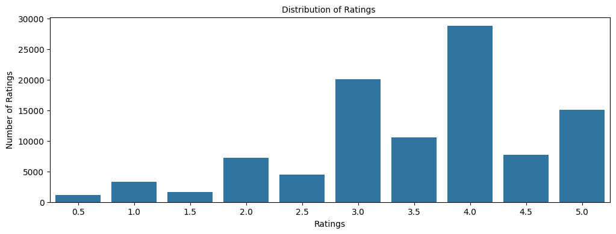

```python
plt.figure(figsize = (12, 4))

# Remove _______and complete the code
sns.countplot(x="rating", data=rating)

plt.tick_params(labelsize = 10)
plt.title("Distribution of Ratings ", fontsize = 10)
plt.xlabel("Ratings", fontsize = 10)
plt.ylabel("Number of Ratings", fontsize = 10)
plt.show()
```

**Escriba su respuesta aquí:**

El recuento más alto lo tiene el rating 4 con más de 25.000 registros, le sigue rating 3 y rating 5.

Existe un sesgo a la izquierda donde las mayores frecuencias están en los rating mayores a 3.

### **P 1.3 ¿Cuál es el número total de usuarios únicos y películas únicas? (1 Punto)**

```python
# Finding number of unique users
#remove _______ and complete the code
rating['userId'].nunique()
```

```
671
```

**Escriba su respuesta aquí:**

671 usuarios

```python
# Finding number of unique movies
# Remove _______ and complete the code

rating['movieId'].nunique()
```

```
9066
```

**Escriba su respuesta aquí:**

9.066 películas únicas

### **P 1.4 ¿Hay alguna película en la que el mismo usuario haya interactuado con ella más de una vez? (1 Punto)**

```python
rating.groupby(['userId', 'movieId']).count()
```

| userId | movieId | rating |
| --- | --- | --- |
| 1 | 31 | 1 |
|  | 1029 | 1 |
|  | 1061 | 1 |
|  | 1129 | 1 |
|  | 1172 | 1 |
| ... | ... | ... |
| 671 | 6268 | 1 |
|  | 6269 | 1 |
|  | 6365 | 1 |
|  | 6385 | 1 |
|  | 6565 | 1 |

100004 rows × 1 columns

```python
rating.groupby(['userId', 'movieId']).count()['rating'].sum()
```

```
100004
```

**Escriba su respuesta aquí:**

### **P 1.5 ¿Cuál es la película con mayor interacción en el conjunto de datos? (1 Punto)**

```python
# Remove _______ and complete the code
rating['movieId'].value_counts()
```

```
movieId
356       341
296       324
318       311
593       304
260       291
         ...
98604       1
103659      1
104419      1
115927      1
6425        1
Name: count, Length: 9066, dtype: int64
```

**Escriba su respuesta aquí:**

La película con más interacción es la 356 con 341 observaciones

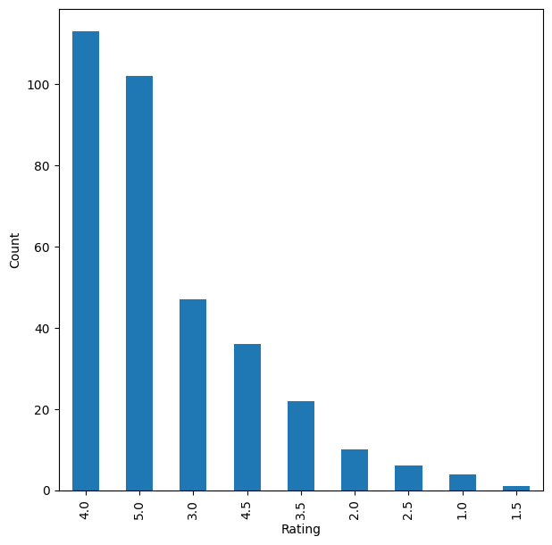

```python
# Plotting distributions of ratings for 341 interactions with movieid 356
plt.figure(figsize=(7,7))
rating[rating['movieId'] == 356]['rating'].value_counts().plot(kind='bar')
plt.xlabel('Rating')
plt.ylabel('Count')
plt.show()
```

**Escriba su respuesta aquí:**

### **P 1.6 ¿Qué usuario interactuó más con cualquier película del conjunto de datos? (1 Punto)**

```python
# Remove _______ and complete the code
rating['userId'].value_counts()
```

```
userId
547    2391
564    1868
624    1735
15     1700
73     1610
       ...
296      20
289      20
249      20
221      20
1        20
Name: count, Length: 671, dtype: int64
```

**Escriba su respuesta aquí:**

El usuario 547 fue el que interactuó más, vio 2391 películas.

### **P 1.7 ¿Cuál es la distribución de las interacciones usuario-película en este conjunto de datos? (1 Punto)**

```python
# Finding user-movie interactions distribution
count_interactions = rating.groupby('userId').count()['movieId']
count_interactions
```

```
userId
1       20
2       76
3       51
4      204
5      100
      ...
667     68
668     20
669     37
670     31
671    115
Name: movieId, Length: 671, dtype: int64
```

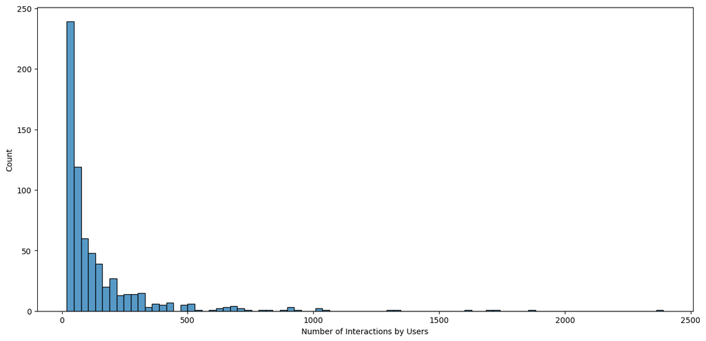

```python
# Plotting user-movie interactions distribution

plt.figure(figsize=(15,7))
# Remove _______ and complete the code
sns.histplot(count_interactions)
plt.xlabel('Number of Interactions by Users')
plt.show()
```

**Escriba su respuesta aquí:**

La distribución está sesgada a la derecha. La gran mayoría de los usuarios interactuaron con menos de 500 películas

#### Como ya hemos explorado los datos, comencemos a construir sistemas de recomendación

## **Pregunta 2: Crear un sistema de recomendación basado en rangos (3 puntos)**

### **Modelo 1: Sistema de recomendación basado en rangos**

Los sistemas de recomendación basados en rangos brindan recomendaciones basadas en los elementos más populares. Este tipo de sistema de recomendación es útil cuando tenemos problemas de **arranque en frío**. El arranque en frío se refiere al problema cuando ingresamos un nuevo usuario al sistema y la máquina no puede recomendar películas al nuevo usuario, ya que el usuario no tuvo interacciones históricas en el conjunto de datos. En esos casos, podemos usar el sistema de recomendación basado en rangos para recomendar películas al nuevo usuario.

Para crear el sistema de recomendación basado en la clasificación, tomamos el **promedio** de todas las calificaciones proporcionadas a cada película y luego las clasificamos en función de su calificación promedio.

```python
# Remove _______ and complete the code

# Calculating average ratings
average_rating = rating.groupby('movieId').mean()["rating"]
# Calculating the count of ratings
count_rating = rating.groupby('movieId').count()["rating"]
# Making a dataframe with the count and average of ratings
final_rating = pd.DataFrame({'avg_rating':average_rating, 'rating_count':count_rating})
```

```python
final_rating.head()
```

| movieId | avg_rating | rating_count |
| --- | --- | --- |
| 1 | 3.872470 | 247 |
| 2 | 3.401869 | 107 |
| 3 | 3.161017 | 59 |
| 4 | 2.384615 | 13 |
| 5 | 3.267857 | 56 |

Ahora, creemos una función para encontrar las **n mejores películas** para una recomendación basada en las calificaciones promedio de las películas. También podemos agregar un **umbral para un número mínimo de interacciones** para que una película sea considerada para recomendación.

```python
def top_n_movies(data, n, min_interaction=100):
    #Finding movies with minimum number of interactions
    recommendations = data[data['rating_count'] >= min_interaction]
    #Sorting values w.r.t average rating
    recommendations = recommendations.sort_values(by='avg_rating', ascending=False)
    return recommendations.index[:n]
```

Podemos **usar esta función con diferentes valores para *n* e interacciones mínimas** para recomendar películas

#### **Recomendación de las 5 mejores películas con 50 interacciones mínimas según su popularidad**

```python
# Remove _______ and complete the code
list(top_n_movies(final_rating, 5, 50))
```

```
[858, 318, 969, 913, 1221]
```

#### **Recomendación de las 5 mejores películas con 100 interacciones mínimas según su popularidad**

```python
# Remove _______ and complete the code
list(top_n_movies(final_rating, 5, 100))
```

```
[858, 318, 1221, 50, 527]
```

#### **Recomendación de las 5 mejores películas con 200 interacciones mínimas según su popularidad**

```python
# Remove _______ and complete the code
list(top_n_movies(final_rating, 5, 200))
```

```
[858, 318, 50, 527, 608]
```

Ahora que hemos visto **cómo aplicar el Sistema de recomendación basado en rangos**, apliquemos los **Sistemas de recomendación basados en filtrado colaborativo**.

## **Modelo 2: Sistema de recomendación de filtrado colaborativo basado en el usuario (7 puntos)**

[figure not shown]

En la **matriz de interacciones** anterior, de los usuarios B y C, ¿qué usuario es más probable que interactúe con la película "La terminal"?

En este tipo de sistema de recomendación, `no necesitamos ninguna información` sobre los usuarios o elementos. Solo necesitamos datos de interacción de elementos del usuario para construir un sistema de recomendación colaborativo. Por ejemplo -

1. **Ratings** proporcionada por los usuarios. Por ejemplo: calificaciones de libros en goodread, calificaciones de películas en imdb, etc.
2. **Likes** de usuarios en diferentes publicaciones de facebook, me gusta en videos de youtube
3. **Use/buying** de un producto por parte de los usuarios. Por ejemplo, comprar diferentes artículos en sitios de comercio electrónico
4. **Reading** de artículos de lectores en varios blogs

**Tipos de filtrado colaborativo**

- Basado en similitud/vecindario
  - Basado en la similitud usuario-usuario
  - Basado en la similitud entre elementos
- Basado en modelos

#### **Creación de filtros colaborativos basados en similitudes/vecindarios**

[figure not shown]

### **Creación de un sistema de recomendación basado en la similitud usuario-usuario**

- A continuación, estamos construyendo **sistemas de recomendación basados en la similitud** usando la similitud del `coseno` y usando **KNN para encontrar usuarios similares** que son los vecinos más cercanos al usuario dado.
- Usaremos una nueva biblioteca, llamada `surprise`, para construir los modelos restantes. Primero importemos las clases y funciones necesarias de esta biblioteca.

A continuación, cargamos el conjunto de datos **`rating`**, que es un **DataFrame** en **pandas**, en un **formato diferente llamado `surprise.dataset.DatasetAutoFolds` que es requerido por esta biblioteca**. Para hacer esto, **utilizaremos las clases `Reader` y `Dataset`**. Finalmente, dividir los datos en conjunto de entrenamiento y conjunto de prueba.

#### **Convertir el conjunto de datos en un conjunto de datos *surprise* y dividirlo en un conjunto de entrenamiento y prueba**

```python
# Instantiating Reader scale with expected rating scale
reader = Reader(rating_scale=(0, 5))

# Loading the rating dataset
data = Dataset.load_from_df(rating[['userId', 'movieId', 'rating']], reader)

# Splitting the data into train and test dataset
trainset, testset = train_test_split(data, test_size=0.2, random_state=42)
```

#### **Cree el primer sistema de recomendación basado en la similitud de referencia utilizando la similitud del coseno y KNN**

```python
# Remove _______ and complete the code
sim_options = {"name": "cosine",
               "user_based": True}

# Defining Nearest neighbour algorithm
algo_knn_user = KNNBasic(sim_options=sim_options, verbose=False)

# Train the algorithm on the trainset or fitting the model on train dataset
algo_knn_user.fit(trainset)

# Predict ratings for the testset
predictions = algo_knn_user.test(testset)

# Then compute RMSE
accuracy.rmse(predictions)
```

```
RMSE: 0.9925
```

```
0.9924509041520163
```

### **P 3.1 ¿Cuál es el RMSE para el sistema de recomendación de filtrado colaborativo basado en el usuario de referencia? (1 Punto)**

**Escriba su respuesta aquí:**

El RMSE es 0.9925

### **P 3.2 ¿Cuál es la calificación prevista para un usuario con userId=4 y movieId=10 y movieId=3? (1 Punto)**

Vamos ahora a predecir la calificación de un usuario con `userId=4` y `movieId=10`

```python
# Remove _______ and complete the code
algo_knn_user.predict(4, 10, r_ui=4, verbose=True)
```

```
user: 4          item: 10         r_ui = 4.00   est = 3.62   {'actual_k': 40, 'was_impossible': False}
```

```
Prediction(uid=4, iid=10, r_ui=4, est=3.6244912065910952, details={'actual_k': 40, 'was_impossible': False})
```

**Escriba su respuesta aquí:**

La calificación prevista es 3.62, 0.38 puntos menos que el valor real

Predigamos la calificación para el mismo `userId=4` pero para una película con la que este usuario no ha interactuado antes, es decir, `movieId=3`

```python
# Remove _______ and complete the code
algo_knn_user.predict(4, 3, verbose=True)
```

```
user: 4          item: 3          r_ui = None   est = 3.20   {'actual_k': 40, 'was_impossible': False}
```

```
Prediction(uid=4, iid=3, r_ui=None, est=3.202703552548654, details={'actual_k': 40, 'was_impossible': False})
```

**Escriba su respuesta aquí:**

La estimación para el usuario 4 para una película que no ha visto (3) es de 3.2

### **Mejora del sistema de recomendaciones basado en la similitud usuario-usuario mediante el ajuste de sus hiperparámetros**

A continuación, ajustaremos hiperparámetros para los algoritmos `KNNBasic`. Tratemos de entender diferentes hiperparámetros del algoritmo KNNBasic -

- **k** (int) – El número (máximo) de vecinos a tener en cuenta para la agregación (ver esta nota). El valor predeterminado es 40.
- **min_k** (int) – El número mínimo de vecinos a tener en cuenta para la agregación. Si no hay suficientes vecinos, la predicción se establece en la media global de todas las calificaciones. El valor predeterminado es 1.
- **sim_options** (dict) – Un diccionario de opciones para la medida de similitud. Hay cuatro medidas de similitud disponibles en librerí a *surprise*:
  - coseno
  - msd (predeterminado)
  - pearson
  - pearson baseline

Para obtener más detalles, consulte la documentación oficial https://surprise.readthedocs.io/en/stable/knn_inspired.html

### **P 3.3 ¿Realizar el ajuste de hiperparámetros para el sistema de recomendación de filtrado colaborativo basado en el usuario de referencia y encontrar el RMSE para el sistema de recomendación de filtrado colaborativo basado en el usuario ajustado? (3 Puntos)**

```python
# Remove _______ and complete the code

# Setting up parameter grid to tune the hyperparameters
param_grid = {"k": [20,30,40], "min_k": [3,6,9],
              "sim_options": {"name": ["msd","cosine"],
                              "user_based": [True]}
              }

# Performing 3-fold cross validation to tune the hyperparameters
grid_obj = GridSearchCV(KNNBasic, param_grid, measures=['rmse', 'mae'], cv=3, n_jobs=-1)

# Fitting the data
grid_obj.fit(data)

# Best RMSE score
print(grid_obj.best_score['rmse'])

# Combination of parameters that gave the best RMSE score
print(grid_obj.best_params['rmse'])
```

```
0.9640183640499337
{'k': 20, 'min_k': 3, 'sim_options': {'name': 'msd', 'user_based': True}}
```

Una vez que la búsqueda en cuadrícula está **completa**, podemos obtener los **valores óptimos para cada uno de esos hiperparámetros** como se muestra arriba.

A continuación, analizamos las métricas de evaluación: RMSE y MAE en todas y cada una de las divisiones para analizar el impacto de cada valor de los hiperparámetros.

```python
results_df = pd.DataFrame.from_dict(grid_obj.cv_results)
results_df.head()
```

|  | split0_test_rmse | split1_test_rmse | split2_test_rmse | mean_test_rmse | std_test_rmse | rank_test_rmse | split0_test_mae | split1_test_mae | split2_test_mae | mean_test_mae | std_test_mae | rank_test_mae | mean_fit_time | std_fit_time | mean_test_time | std_test_time | params | param_k | param_min_k | param_sim_options |
| --- | --- | --- | --- | --- | --- | --- | --- | --- | --- | --- | --- | --- | --- | --- | --- | --- | --- | --- | --- | --- |
| 0 | 0.965566 | 0.963732 | 0.962757 | 0.964018 | 0.001164 | 1 | 0.744551 | 0.739670 | 0.740690 | 0.741637 | 0.002102 | 1 | 0.272166 | 0.081425 | 4.374833 | 1.026838 | {'k': 20, 'min_k': 3, 'sim_options': {'name': ... | 20 | 3 | {'name': 'msd', 'user_based': True} |
| 1 | 0.994967 | 0.992846 | 0.991272 | 0.993028 | 0.001514 | 13 | 0.771148 | 0.766550 | 0.766407 | 0.768035 | 0.002202 | 12 | 0.302278 | 0.086355 | 2.918774 | 0.022860 | {'k': 20, 'min_k': 3, 'sim_options': {'name': ... | 20 | 3 | {'name': 'cosine', 'user_based': True} |
| 2 | 0.970981 | 0.965840 | 0.967752 | 0.968191 | 0.002122 | 3 | 0.748291 | 0.741449 | 0.744267 | 0.744669 | 0.002808 | 3 | 0.184163 | 0.046343 | 4.441873 | 1.067389 | {'k': 20, 'min_k': 6, 'sim_options': {'name': ... | 20 | 6 | {'name': 'msd', 'user_based': True} |
| 3 | 0.998982 | 0.993075 | 0.994422 | 0.995493 | 0.002528 | 15 | 0.773705 | 0.766912 | 0.768490 | 0.769702 | 0.002903 | 15 | 0.280097 | 0.058067 | 2.861891 | 0.076406 | {'k': 20, 'min_k': 6, 'sim_options': {'name': ... | 20 | 6 | {'name': 'cosine', 'user_based': True} |
| 4 | 0.977548 | 0.972693 | 0.972900 | 0.974380 | 0.002242 | 7 | 0.753621 | 0.747528 | 0.748348 | 0.749832 | 0.002700 | 6 | 0.230527 | 0.012517 | 3.685222 | 0.139473 | {'k': 20, 'min_k': 9, 'sim_options': {'name': ... | 20 | 9 | {'name': 'msd', 'user_based': True} |

```python
# Remove _______ and complete the code

# Using the optimal similarity measure for user-user based collaborative filtering
# Creating an instance of KNNBasic with optimal hyperparameter values
similarity_algo_optimized_user = KNNBasic(sim_options=sim_options, k=40, min_k=6,verbose=False)

# Training the algorithm on the trainset
similarity_algo_optimized_user.fit(trainset)

# Predicting ratings for the testset
predictions = similarity_algo_optimized_user.test(testset)

# Computing RMSE on testset
accuracy.rmse(predictions)
```

```
RMSE: 0.9908
```

```
0.9907613369496804
```

**Escriba su respuesta aquí:**

### **P 3.4 ¿Cuál es la calificación prevista para un usuario con ID de usuario = 4 y para ID de película = 10 y ID de película = 3 usando filtrado colaborativo basado en usuarios ajustados? (1 Punto)**

Ahora vamos a predecir la calificación de un usuario con `userId=4` y `movieId=10` con el modelo optimizado

```python
# Remove _______ and complete the code
similarity_algo_optimized_user.predict(4,10, r_ui=4, verbose=True)
```

```
user: 4          item: 10         r_ui = 4.00   est = 3.62   {'actual_k': 40, 'was_impossible': False}
```

```
Prediction(uid=4, iid=10, r_ui=4, est=3.6244912065910952, details={'actual_k': 40, 'was_impossible': False})
```

**Escriba su respuesta aquí:**

Es de 3.62, similar a la estimación usando el sistema colaborativo por usuario sin hiperparámetro.

A continuación, predecimos la calificación para el mismo `userId=4` pero para una película con la que este usuario no ha interactuado antes, es decir, `movieId=3`, mediante el uso del modelo optimizado como se muestra a continuación:

```python
# Remove _______ and complete the code
similarity_algo_optimized_user.predict(4,3, verbose=True)
```

```
user: 4          item: 3          r_ui = None   est = 3.20   {'actual_k': 40, 'was_impossible': False}
```

```
Prediction(uid=4, iid=3, r_ui=None, est=3.202703552548654, details={'actual_k': 40, 'was_impossible': False})
```

**Escriba su respuesta aquí:**

La estimación es 3.2, similar al modelo antes utilizado.

### **Identificación de usuarios similares a un usuario dado (vecinos más cercanos)**

```python
similarity_algo_optimized_user.get_neighbors(4, k=5)
```

```
[357, 220, 590, 491, 647]
```

### **Implementación del algoritmo de recomendación basado en el modelo KNNBasic optimizado**

A continuación, implementaremos una función donde los parámetros de entrada son:

- data: un conjunto de datos de calificación
- user_id: una identificación de usuario contra la cual queremos las recomendaciones
- top_n: el número de películas que queremos recomendar
- algo: el algoritmo que queremos usar para predecir las calificaciones

```python
def get_recommendations(data, user_id, top_n, algo):

    # Creating an empty list to store the recommended movie ids
    recommendations = []

    # Creating an user item interactions matrix
    user_item_interactions_matrix = data.pivot(index='userId', columns='movieId', values='rating')

    # Extracting those movie ids which the user_id has not interacted yet
    non_interacted_movies = user_item_interactions_matrix.loc[user_id][user_item_interactions_matrix.loc[user_id].isnull()].index.tolist()

    # Looping through each of the movie id which user_id has not interacted yet
    for item_id in non_interacted_movies:

        # Predicting the ratings for those non interacted movie ids by this user
        est = algo.predict(user_id, item_id).est

        # Appending the predicted ratings
        recommendations.append((item_id, est))

    # Sorting the predicted ratings in descending order
    recommendations.sort(key=lambda x: x[1], reverse=True)

    return recommendations[:top_n] # returing top n highest predicted rating movies for this user
```

#### **Las 5 mejores películas pronosticadas para userId=4 con sistema de recomendación basado en similitudes**

```python
#remove _______ and complete the code
recommendations = get_recommendations(rating,4,5,similarity_algo_optimized_user)
```

### **P 3.5 Prediga las 5 mejores películas para ID de usuario = 4 con un sistema de recomendación basado en similitudes (1 punto)**

```python
recommendations
```

```
[(98491, 4.832340578646058),
 (116, 4.753206589295344),
 (6669, 4.748048450384675),
 (1221, 4.662571141751736),
 (1192, 4.65824768595177)]
```

## **Modelo 3: Sistema de recomendación de filtrado colaborativo basado en elementos (7 puntos)**

```python
# Remove _______ and complete the code

# Definfing similarity measure
sim_options = {"name": "cosine",
               "user_based": False}

# Defining Nearest neighbour algorithm
algo_knn_item = KNNBasic(sim_options=sim_options,verbose=False)

# Train the algorithm on the trainset or fitting the model on train dataset
algo_knn_item.fit(trainset)

# Predict ratings for the testset
predictions = algo_knn_item.test(testset)

# Then compute RMSE
accuracy.rmse(predictions)
```

```
RMSE: 1.0032
```

```
1.003221450633729
```

### **P 4.1 ¿Cuál es el RMSE para el sistema de recomendación de filtrado colaborativo basado en elementos de referencia? (1 punto)**

**Escriba su respuesta aquí:**

Vamos ahora a predecir la calificación de un usuario con `userId=4` y `movieId=10`

### **P 4.2 ¿Cuál es la calificación prevista para un usuario con ID de usuario = 4 y para ID de película = 10 y ID de película = 3? (1 Punto)**

```python
# Remove _______ and complete the code
algo_knn_item.predict(4,10, r_ui=4, verbose=True)
```

```
user: 4          item: 10         r_ui = 4.00   est = 4.37   {'actual_k': 40, 'was_impossible': False}
```

```
Prediction(uid=4, iid=10, r_ui=4, est=4.373794871885004, details={'actual_k': 40, 'was_impossible': False})
```

**Escriba su respuesta aquí:**

La estimación es de 4.37, por sobre el valor del rating real 4.

Predigamos la calificación para el mismo `userId=4` pero para una película con la que este usuario no ha interactuado antes, es decir, `movieId=3`

```python
# Remove _______ and complete the code
algo_knn_item.predict(4,3, verbose=True)
```

```
user: 4          item: 3          r_ui = None   est = 4.07   {'actual_k': 40, 'was_impossible': False}
```

```
Prediction(uid=4, iid=3, r_ui=None, est=4.071601862880049, details={'actual_k': 40, 'was_impossible': False})
```

**Escriba su respuesta aquí:**

La estimación es de 4.07

### **P 4.3 ¿Realizar el ajuste de hiperparámetros para el sistema de recomendación de filtrado colaborativo basado en elementos de referencia y encontrar el RMSE para el sistema de recomendación de filtrado colaborativo basado en elementos ajustados? (3 Puntos)**

```python
# Remove _______ and complete the code

# Setting up parameter grid to tune the hyperparameters
param_grid = {"k": [20,30,40], "min_k": [3,6,9],
              "sim_options": {"name": ["msd","cosine"],
                              "user_based": [True]}}

# Performing 3-fold cross validation to tune the hyperparameters
grid_obj = GridSearchCV(KNNBasic, param_grid, measures=['rmse', 'mae'], cv=3, n_jobs=-1)

# Fitting the data
grid_obj.fit(data)

# Best RMSE score
print(grid_obj.best_score['rmse'])

# Combination of parameters that gave the best RMSE score
print(grid_obj.best_params['rmse'])
```

```
0.9644644258003189
{'k': 20, 'min_k': 3, 'sim_options': {'name': 'msd', 'user_based': True}}
```

Una vez que se completa la **búsqueda en cuadrícula**, podemos obtener los **valores óptimos para cada uno de esos hiperparámetros como se muestra arriba**

A continuación, analizamos las métricas de evaluación: RMSE y MAE en todas y cada una de las divisiones para analizar el impacto de cada valor de los hiperparámetros.

```python
results_df = pd.DataFrame.from_dict(grid_obj.cv_results)
results_df.head()
```

|  | split0_test_rmse | split1_test_rmse | split2_test_rmse | mean_test_rmse | std_test_rmse | rank_test_rmse | split0_test_mae | split1_test_mae | split2_test_mae | mean_test_mae | std_test_mae | rank_test_mae | mean_fit_time | std_fit_time | mean_test_time | std_test_time | params | param_k | param_min_k | param_sim_options |
| --- | --- | --- | --- | --- | --- | --- | --- | --- | --- | --- | --- | --- | --- | --- | --- | --- | --- | --- | --- | --- |
| 0 | 0.959767 | 0.971276 | 0.962351 | 0.964464 | 0.004930 | 1 | 0.737570 | 0.745084 | 0.740892 | 0.741182 | 0.003074 | 1 | 0.199482 | 0.101860 | 3.012136 | 0.196285 | {'k': 20, 'min_k': 3, 'sim_options': {'name': ... | 20 | 3 | {'name': 'msd', 'user_based': True} |
| 1 | 0.987698 | 0.999053 | 0.990913 | 0.992555 | 0.004779 | 12 | 0.762905 | 0.770464 | 0.767004 | 0.766791 | 0.003090 | 12 | 0.346718 | 0.107371 | 3.655862 | 0.210175 | {'k': 20, 'min_k': 3, 'sim_options': {'name': ... | 20 | 3 | {'name': 'cosine', 'user_based': True} |
| 2 | 0.964260 | 0.976113 | 0.966071 | 0.968814 | 0.005213 | 4 | 0.741065 | 0.749634 | 0.743857 | 0.744852 | 0.003568 | 3 | 0.132670 | 0.030021 | 2.858303 | 0.047294 | {'k': 20, 'min_k': 6, 'sim_options': {'name': ... | 20 | 6 | {'name': 'msd', 'user_based': True} |
| 3 | 0.990366 | 1.002765 | 0.993629 | 0.995587 | 0.005248 | 15 | 0.764918 | 0.774136 | 0.769218 | 0.769424 | 0.003766 | 15 | 0.196806 | 0.021186 | 3.546081 | 0.551811 | {'k': 20, 'min_k': 6, 'sim_options': {'name': ... | 20 | 6 | {'name': 'cosine', 'user_based': True} |
| 4 | 0.970777 | 0.983179 | 0.971420 | 0.975125 | 0.005701 | 7 | 0.746391 | 0.755637 | 0.748826 | 0.750285 | 0.003913 | 7 | 0.236482 | 0.065187 | 2.850992 | 0.091678 | {'k': 20, 'min_k': 9, 'sim_options': {'name': ... | 20 | 9 | {'name': 'msd', 'user_based': True} |

```python
# Remove _______ and complete the code
# Creating an instance of KNNBasic with optimal hyperparameter values
similarity_algo_optimized_item = KNNBasic(sim_options={"name": "msd", "user_based": False}, k=30, min_k=6,verbose=False)

# Training the algorithm on the trainset
similarity_algo_optimized_item.fit(trainset)

# Predicting ratings for the testset
predictions = similarity_algo_optimized_item.test(testset)

# Computing RMSE on testset
accuracy.rmse(predictions)
```

```
RMSE: 0.9465
```

```
0.9465120620317036
```

**Escriba su respuesta aquí:**

El modelo de sistema colaborativo basado en elementos ajustado a hiperparámetro es el mejor hasta el momento ya que posee el menor RMSE con 0.9465.

### **P 4.4 ¿Cuál es la calificación prevista para un elemento con ID de usuario = 4 y para ID de película = 10 y ID de película = 3 usando filtrado colaborativo basado en elementos ajustados? (1 Punto)**

Vamos ahora a predecir la calificación de un usuario con `userId=4` y `movieId=10` con el modelo optimizado como se muestra a continuación

```python
# Remove _______ and complete the code
similarity_algo_optimized_item.predict(4,10, r_ui=4, verbose=True)
```

```
user: 4          item: 10         r_ui = 4.00   est = 4.30   {'actual_k': 30, 'was_impossible': False}
```

```
Prediction(uid=4, iid=10, r_ui=4, est=4.298279280483517, details={'actual_k': 30, 'was_impossible': False})
```

**Escriba su respuesta aquí:**

Predigamos la calificación para el mismo `userId=4` pero para una película con la que este usuario no ha interactuado antes, es decir, `movieId=3`, usando el modelo optimizado:

```python
# Remove _______ and complete the code
similarity_algo_optimized_item.predict(4, 3, verbose=True)
```

```
user: 4          item: 3          r_ui = None   est = 3.86   {'actual_k': 30, 'was_impossible': False}
```

```
Prediction(uid=4, iid=3, r_ui=None, est=3.859023126306401, details={'actual_k': 30, 'was_impossible': False})
```

**Escriba su respuesta aquí:**

Es de 3.86 la predicción

### **Identificar elementos similares a un elemento dado (vecinos más cercanos)**

También podemos averiguar los elementos similares a un elemento determinado o sus vecinos más cercanos en función de este algoritmo KNNBasic. A continuación, encontramos los 5 elementos más similares a `movieId=3` según la métrica de distancia `msd`

```python
# Remove _______ and complete the code
similarity_algo_optimized_item.get_neighbors(3, k=5)
```

```
[31, 37, 42, 48, 73]
```

#### **Las 5 mejores películas pronosticadas para userId=4 con sistema de recomendación basado en similitudes**

```python
# Remove _______ and complete the code
recommendations = get_recommendations(rating, 4, 5, similarity_algo_optimized_item)
```

### **P 4.5 Prediga las 5 mejores películas para userId=4 con un sistema de recomendación basado en similitudes (1 punto)**

```python
recommendations
```

```
[(84, 5), (1040, 5), (2481, 5), (3515, 5), (4521, 5)]
```

## **Modelo 4: Filtrado colaborativo - Factorización de matrices usando SVD (7 puntos)**

El filtrado colaborativo basado en modelos es un **sistema de recomendaciones personalizadas**, las recomendaciones se basan en el comportamiento anterior del usuario y no dependen de ninguna información adicional. Usamos **características latentes** para encontrar recomendaciones para cada usuario.

**Características latentes:** Las características que no están presentes en los datos empíricos pero que se pueden inferir de los datos. Por ejemplo:

[figure not shown]

Ahora bien, si nos fijamos en las películas anteriores de cerca:

[figure not shown]

Aquí **Acción**, **Romance**, **Suspenso** y **Comedia** son características latentes de las películas correspondientes. De manera similar, podemos calcular las características latentes para los usuarios como se muestra a continuación:

[figure not shown]

### **Descomposición de valores singulares (SVD)**

SVD se utiliza para **calcular las características latentes** de la **matriz de elementos de usuario**. Pero SVD no funciona cuando **perdemos valores** en la **matriz de elementos de usuario**.

Primero necesitamos convertir el siguiente conjunto de datos de clasificación de películas:

[figure not shown]

en una matriz de elementos de usuario como se muestra a continuación:

[figure not shown]

Ya hemos hecho esto anteriormente mientras calculamos similitudes de coseno.

**SVD descompone esta matriz anterior en tres matrices separadas:**

- Matriz U
- Matriz Sigma
- Matriz transpuesta V

#### **Matriz U**

[figure not shown]

la matriz anterior es una matriz n x k, donde:

- n es el número de usuarios
- k es el número de características latentes

#### **Matriz Sigma**

[figure not shown]

la matriz anterior es una matriz k x k, donde:

- k es el número de características latentes
- cada entrada diagonal es el valor singular de la matriz de interacción original.

#### **Matriz transpuesta en V**

[figure not shown]

la matriz anterior es una matriz kxn, donde:

- k es el número de características latentes
- n es el número de elementos

### **Construir un sistema de recomendación de factorización de matriz de referencia**

```python
# Remove _______ and complete the code

# Using SVD matrix factorization
algo_svd = SVD()

# Training the algorithm on the trainset
algo_svd.fit(trainset)

# Predicting ratings for the testset
predictions = algo_svd.test(testset)

# Computing RMSE on the testset
accuracy.rmse(predictions)
```

```
RMSE: 0.9025
```

```
0.9025328108755364
```

### **P 5.1 ¿Qué es el RMSE para el sistema de recomendación de filtrado colaborativo basado en SVD de referencia? (1 Punto)**

**Escriba su respuesta aquí:**

El modelo arroja un RMSE de 0.9025, el más bajo comparado a los 4 modelos anteriores.

### **P 5.2 ¿Cuál es la calificación prevista para un usuario con ID de usuario = 4 y para ID de película = 10 y ID de película = 3? (1 Punto)**

Vamos ahora a predecir la calificación de un usuario con `userId=4` y `movieId=10`

```python
# Remove _______ and complete the code
algo_svd.predict(4, 10, r_ui=4, verbose=True)
```

```
user: 4          item: 10         r_ui = 4.00   est = 3.90   {'was_impossible': False}
```

```
Prediction(uid=4, iid=10, r_ui=4, est=3.8986947736329305, details={'was_impossible': False})
```

**Escriba su respuesta aquí:**

Aquí la predicción (3.9) es bastante cercana al valor real (4) con una diferencia de 0.1 puntos.

Vamos a predecir la calificación para el mismo `userId=4` pero para una película con la que este usuario no ha interactuado antes, es decir, `movieId=3`:

```python
# Remove _______ and complete the code
algo_svd.predict(4, 3, verbose=True)
```

```
user: 4          item: 3          r_ui = None   est = 3.42   {'was_impossible': False}
```

```
Prediction(uid=4, iid=3, r_ui=None, est=3.4181350761188787, details={'was_impossible': False})
```

**Escriba su respuesta aquí:**

La predicción predicha es de 3.42

### **Mejora del sistema de recomendación basado en la factorización de matrices mediante el ajuste de sus hiperparámetros**

En SVD, la calificación se predice como -

$$\hat{r}_{u i}=\mu+b_{u}+b_{i}+q_{i}^{T} p_{u}$$

Si se desconoce el usuario $u$, se supone que el sesgo $b_{u}$ y los factores $p_{u}$ son cero. Lo mismo aplica para el ítem $i$ con $b_{i}$ y $q_{i}$.

Para estimar todas las incógnitas, minimizamos el siguiente error cuadrático regularizado:

$$\sum_{r_{u i} \in R_{\text {train }}}\left(r_{u i}-\hat{r}_{u i}\right)^{2}+\lambda\left(b_{i}^{2}+b_{u}^{2}+\left\|q_{i}\right\|^{2}+\left\|p_{u}\right\|^{2}\right)$$

La minimización se realiza mediante el método de **descenso de gradiente estocástico**:

$$\begin{aligned} b_{u} & \leftarrow b_{u}+\gamma\left(e_{u i}-\lambda b_{u}\right) \\ b_{i} & \leftarrow b_{i}+\gamma\left(e_{u i}-\lambda b_{i}\right) \\ p_{u} & \leftarrow p_{u}+\gamma\left(e_{u i} \cdot q_{i}-\lambda p_{u}\right) \\ q_{i} & \leftarrow q_{i}+\gamma\left(e_{u i} \cdot p_{u}-\lambda q_{i}\right) \end{aligned}$$

Hay muchos hiperparámetros para ajustar este algoritmo, puede encontrar una lista completa de hiperparámetros [aquí](https://surprise.readthedocs.io/en/stable/matrix_factorization.html#surprise.prediction_algorithms.matrix_factorization.SVD)

A continuación, ajustaremos solo tres hiperparámetros:

- **n_epochs**: El número de iteraciones del algoritmo SGD
- **lr_all**: La tasa de aprendizaje para todos los parámetros
- **reg_all**: El término de regularización para todos los parámetros

### **P 5.3 ¿Realizar el ajuste de hiperparámetros para el sistema de recomendación de filtrado colaborativo basado en SVD de referencia y encontrar el RMSE para el sistema de recomendación de filtrado colaborativo basado en SVD ajustado? (3 Puntos)**

```python
# Remove _______ and complete the code

# Set the parameter space to tune
param_grid = {'n_epochs': [10, 20, 30], 'lr_all': [0.001, 0.005, 0.01],
              'reg_all': [0.2, 0.4, 0.6]}

# Performing 3-fold gridsearch cross validation
gs = GridSearchCV(SVD, param_grid, measures=['rmse', 'mae'], cv=3, n_jobs=-1)

# Fitting data
gs.fit(data)

# Best RMSE score
print(gs.best_score['rmse'])

# Combination of parameters that gave the best RMSE score
print(gs.best_params['rmse'])
```

```
0.8944074784708146
{'n_epochs': 30, 'lr_all': 0.01, 'reg_all': 0.2}
```

Una vez que se completa la **búsqueda en cuadrícula**, podemos obtener los **valores óptimos** para cada uno de esos hiperparámetros, como se muestra arriba.

A continuación, analizamos las métricas de evaluación: RMSE y MAE en todas y cada una de las divisiones para analizar el impacto de cada valor de los hiperparámetros.

```python
results_df = pd.DataFrame.from_dict(gs.cv_results)
results_df.head()
```

|  | split0_test_rmse | split1_test_rmse | split2_test_rmse | mean_test_rmse | std_test_rmse | rank_test_rmse | split0_test_mae | split1_test_mae | split2_test_mae | mean_test_mae | std_test_mae | rank_test_mae | mean_fit_time | std_fit_time | mean_test_time | std_test_time | params | param_n_epochs | param_lr_all | param_reg_all |
| --- | --- | --- | --- | --- | --- | --- | --- | --- | --- | --- | --- | --- | --- | --- | --- | --- | --- | --- | --- | --- |
| 0 | 0.942416 | 0.945544 | 0.942120 | 0.943360 | 0.001549 | 25 | 0.736722 | 0.741375 | 0.736536 | 0.738211 | 0.002238 | 25 | 1.161984 | 0.188773 | 0.608740 | 0.083711 | {'n_epochs': 10, 'lr_all': 0.001, 'reg_all': 0.2} | 10 | 0.001 | 0.2 |
| 1 | 0.947176 | 0.949840 | 0.946732 | 0.947916 | 0.001372 | 26 | 0.742544 | 0.746555 | 0.741684 | 0.743594 | 0.002123 | 26 | 1.782521 | 0.259470 | 0.777107 | 0.053393 | {'n_epochs': 10, 'lr_all': 0.001, 'reg_all': 0.4} | 10 | 0.001 | 0.4 |
| 2 | 0.952515 | 0.955047 | 0.951464 | 0.953009 | 0.001504 | 27 | 0.748399 | 0.752361 | 0.746444 | 0.749068 | 0.002461 | 27 | 1.085360 | 0.091115 | 0.530386 | 0.078461 | {'n_epochs': 10, 'lr_all': 0.001, 'reg_all': 0.6} | 10 | 0.001 | 0.6 |
| 3 | 0.906184 | 0.908371 | 0.906360 | 0.906972 | 0.000992 | 10 | 0.701686 | 0.704654 | 0.701154 | 0.702498 | 0.001540 | 9 | 0.971511 | 0.062196 | 0.483676 | 0.088432 | {'n_epochs': 10, 'lr_all': 0.005, 'reg_all': 0.2} | 10 | 0.005 | 0.2 |
| 4 | 0.914148 | 0.915465 | 0.913477 | 0.914363 | 0.000826 | 15 | 0.709856 | 0.712799 | 0.708720 | 0.710458 | 0.001719 | 15 | 0.926885 | 0.015707 | 0.386941 | 0.011984 | {'n_epochs': 10, 'lr_all': 0.005, 'reg_all': 0.4} | 10 | 0.005 | 0.4 |

```python
# Remove _______ and complete the code

# Building the optimized SVD model using optimal hyperparameter search
svd_algo_optimized = SVD(n_epochs=20, lr_all=0.01, reg_all=0.2)

# Training the algorithm on the trainset
svd_algo_optimized.fit(trainset)

# Predicting ratings for the testset
predictions = svd_algo_optimized.test(testset)

# Computing RMSE
accuracy.rmse(predictions)
```

```
RMSE: 0.8969
```

```
0.8969034897126521
```

### **P 5.4 ¿Cuál es la calificación prevista para un usuario con ID de usuario = 4 y para ID de película = 10 y ID de película = 3 usando filtrado colaborativo basado en SVD? (1 Punto)**

Ahora vamos a predecir la calificación de un usuario con `userId=4` y `movieId=10` con el modelo optimizado

```python
# Remove _______ and complete the code
svd_algo_optimized.predict(4, 10, r_ui=4, verbose=True)
```

```
user: 4          item: 10         r_ui = 4.00   est = 3.98   {'was_impossible': False}
```

```
Prediction(uid=4, iid=10, r_ui=4, est=3.9827944815258123, details={'was_impossible': False})
```

**Escriba su respuesta aquí:**

Dado el RMSE de 0.8969 de este modelo, se logra una predicción casi perfecta al valor real de 3.98 vs 4.

Predigamos la calificación para el mismo `userId=4` pero para una película con la que este usuario no ha interactuado antes, es decir, `movieId=3`:

```python
# Remove _______ and complete the code
svd_algo_optimized.predict(4, 3, verbose=True)
```

```
user: 4          item: 3          r_ui = None   est = 3.64   {'was_impossible': False}
```

```
Prediction(uid=4, iid=3, r_ui=None, est=3.6431193998570546, details={'was_impossible': False})
```

### **P 5.5 ¿Predecir las 5 mejores películas para userId=4 con el sistema de recomendación basado en SVD? (1 punto)**

```python
# Remove _______ and complete the code
get_recommendations(rating, 4, 5, svd_algo_optimized)
```

```
[(926, 4.931680374955583),
 (1217, 4.870554812169171),
 (1192, 4.867235300438458),
 (3035, 4.863756007214046),
 (969, 4.85206019575528)]
```

### **Predicción de calificaciones para películas ya interactuadas**

A continuación, comparamos las predicciones de calificación de los usuarios para aquellas películas que ya ha visto un usuario. Esto nos ayudará a comprender qué tan buenas son las predicciones en comparación con las calificaciones reales proporcionadas por los usuarios.

```python
def predict_already_interacted_ratings(data, user_id, algo):

    # Creating an empty list to store the recommended movie ids
    recommendations = []

    # Creating an user item interactions matrix
    user_item_interactions_matrix = data.pivot(index='userId', columns='movieId', values='rating')

    # Extracting those movie ids which the user_id has interacted already
    interacted_movies = user_item_interactions_matrix.loc[user_id][user_item_interactions_matrix.loc[user_id].notnull()].index.tolist()

    # Looping through each of the movie id which user_id has interacted already
    for item_id in interacted_movies:

        # Extracting actual ratings
        actual_rating = user_item_interactions_matrix.loc[user_id, item_id]

        # Predicting the ratings for those non interacted movie ids by this user
        predicted_rating = algo.predict(user_id, item_id).est

        # Appending the predicted ratings
        recommendations.append((item_id, actual_rating, predicted_rating))

    # Sorting the predicted ratings in descending order
    recommendations.sort(key=lambda x: x[1], reverse=True)

    return pd.DataFrame(recommendations, columns=['movieId', 'actual_rating', 'predicted_rating']) # returing top n highest predicted rating movies for this user
```

Aquí estamos comparando las calificaciones pronosticadas por el sistema de "recomendación basada en la similitud" con las calificaciones reales para "userId=7".

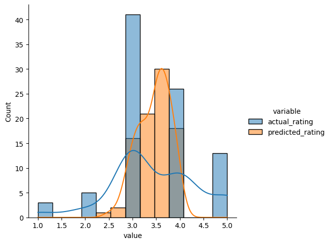

```python
predicted_ratings_for_interacted_movies = predict_already_interacted_ratings(rating, 7, similarity_algo_optimized_item)
df = predicted_ratings_for_interacted_movies.melt(id_vars='movieId', value_vars=['actual_rating', 'predicted_rating'])
sns.displot(data=df, x='value', hue='variable', kde=True);
```

**Escriba su respuesta aquí:**

Se aprecia que ambas distribuciones siguen un comportamiento similar donde el mayor volumen se encuentre entre el rating 3 y 4

A continuación, comparamos las calificaciones pronosticadas por el sistema de "recomendaciones basadas en la factorización matricial" con las calificaciones reales para "userId=7".

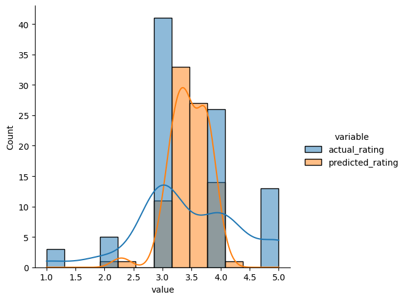

```python
predicted_ratings_for_interacted_movies = predict_already_interacted_ratings(rating, 7, svd_algo_optimized)
df = predicted_ratings_for_interacted_movies.melt(id_vars='movieId', value_vars=['actual_rating', 'predicted_rating'])
sns.displot(data=df, x='value', hue='variable', kde=True);
```

```python
# Instantiating Reader scale with expected rating scale
reader = Reader(rating_scale=(0, 5))

# Loading the rating dataset
data = Dataset.load_from_df(rating[['userId', 'movieId', 'rating']], reader)

# Splitting the data into train and test dataset
trainset, testset = train_test_split(data, test_size=0.2, random_state=42)
```

## **Precisión y Recall @ k**

RMSE no es la única métrica que podemos usar aquí. También podemos examinar dos medidas fundamentales, precisión y recall. También agregamos un parámetro k que es útil para comprender problemas con múltiples salidas de calificación.

**Precisión@k**: es la **fracción de los elementos recomendados que son relevantes en las predicciones `top k`**. El valor de k es el número de recomendaciones que se proporcionarán al usuario. Se puede elegir un número variable de recomendaciones para dar a un usuario único.

**Recall@k**: es la **fracción de elementos relevantes que se recomiendan al usuario en las predicciones `top k`**.

**Recall**: es la **fracción de elementos realmente relevantes que se recomiendan al usuario** es decir, si de 10 películas relevantes, se recomiendan 6 al usuario, entonces el valor de recall es 0,60 . Cuanto mayor sea el valor de recall mejor es el modelo. Es una de las métricas para realizar la evaluación del rendimiento de los modelos de clasificación.

**Precisión**: es la **fracción de elementos recomendados que son realmente relevantes**, es decir, si de 10 elementos recomendados, el usuario considera que 6 son relevantes, entonces la precisión es 0,60. Cuanto mayor sea el valor de la precisión mejor es el modelo. Es una de las métricas para realizar la evaluación del rendimiento de los modelos de clasificación.

Consulte la sección Precisión y recall @k de su cuaderno Jypiter y siga las instrucciones para calcular varios valores de precisión/recall en varios valores de k.

Para obtener más información sobre precisión y recall en los sistemas de recomendación, consulte estos enlaces:

https://surprise.readthedocs.io/en/stable/FAQ.html

https://medium.com/@m_n_malaeb/recall-and-precision-at-k-for-recommender-systems-618483226c54

### **Pregunta 6: Calcule la precisión y el valor recall, para cada uno de los 6 modelos, en k = 5 y 10. ¿Esto es 6 x 2 = 12 valores numéricos? (4 puntos)**

```python
# Function can be found on surprise documentation FAQs
def precision_recall_at_k(predictions, k=10, threshold=3.5):
    """Return precision and recall at k metrics for each user"""

    # First map the predictions to each user.
    user_est_true = defaultdict(list)
    for uid, _, true_r, est, _ in predictions:
        user_est_true[uid].append((est, true_r))

    precisions = dict()
    recalls = dict()
    for uid, user_ratings in user_est_true.items():

        # Sort user ratings by estimated value
        user_ratings.sort(key=lambda x: x[0], reverse=True)

        # Number of relevant items
        n_rel = sum((true_r >= threshold) for (_, true_r) in user_ratings)

        # Number of recommended items in top k
        n_rec_k = sum((est >= threshold) for (est, _) in user_ratings[:k])

        # Number of relevant and recommended items in top k
        n_rel_and_rec_k = sum(((true_r >= threshold) and (est >= threshold))
                              for (est, true_r) in user_ratings[:k])

        # Precision@K: Proportion of recommended items that are relevant
        # When n_rec_k is 0, Precision is undefined. We here set it to 0.

        precisions[uid] = n_rel_and_rec_k / n_rec_k if n_rec_k != 0 else 0

        # Recall@K: Proportion of relevant items that are recommended
        # When n_rel is 0, Recall is undefined. We here set it to 0.

        recalls[uid] = n_rel_and_rec_k / n_rel if n_rel != 0 else 0

    return precisions, recalls
```

```python
# A basic cross-validation iterator.
kf = KFold(n_splits=5)

# Make list of k values
K = [5, 10]

# Remove _______ and complete the code
# Make list of models
models = [algo_knn_user, similarity_algo_optimized_user, algo_knn_item, similarity_algo_optimized_item, algo_svd, svd_algo_optimized]

#algo_knn_user: Sistema recomendacion filtrado colaborativo (no necesitamos nada de info previa) solo la interaccion de elementos del usuario
#similarity_algo_optimized_user: Sistema de recomendacion en similitud mediante ajuste de hiperparametro
#algo_knn_item: Sitema recomendacion filtrado colaborativo basado en elementos
#similarity_algo_optimized_item: Sistema de recomendacion en elementos mediante ajuste de hiperparametro
#algo_svd: Factorizacion matrices usando SVD, depende de info historica
#svd_algo_optimized: SVD en hiperparametro

#Total: 6 modelos

for k in K:
    for model in models:
        print('> k={}, model={}'.format(k,model.__class__.__name__))
        p = []
        r = []
        for trainset, testset in kf.split(data):
            model.fit(trainset)
            predictions = model.test(testset, verbose=False)
            precisions, recalls = precision_recall_at_k(predictions, k=k, threshold=3.5)

            # Precision and recall can then be averaged over all users
            p.append(sum(prec for prec in precisions.values()) / len(precisions))
            r.append(sum(rec for rec in recalls.values()) / len(recalls))

        print('-----> Precision: ', round(sum(p) / len(p), 3))
        print('-----> Recall: ', round(sum(r) / len(r), 3))
```

```
> k=5, model=KNNBasic
-----> Precision:  0.766
-----> Recall:  0.411
> k=5, model=KNNBasic
-----> Precision:  0.768
-----> Recall:  0.417
> k=5, model=KNNBasic
-----> Precision:  0.608
-----> Recall:  0.326
> k=5, model=KNNBasic
-----> Precision:  0.684
-----> Recall:  0.357
> k=5, model=SVD
-----> Precision:  0.759
-----> Recall:  0.387
> k=5, model=SVD
-----> Precision:  0.75
-----> Recall:  0.382
> k=10, model=KNNBasic
-----> Precision:  0.75
-----> Recall:  0.548
> k=10, model=KNNBasic
-----> Precision:  0.746
-----> Recall:  0.563
> k=10, model=KNNBasic
-----> Precision:  0.6
-----> Recall:  0.476
> k=10, model=KNNBasic
-----> Precision:  0.661
-----> Recall:  0.506
> k=10, model=SVD
-----> Precision:  0.734
-----> Recall:  0.523
> k=10, model=SVD
-----> Precision:  0.728
-----> Recall:  0.522
```

### **Pregunta 7 (5 Puntos)**

**7.1 Comparar los resultados de los modelos basedos en usuario-usuario y elemento-elemento.**

**7.2 ¿Cómo se comparan estos modelos de referencia entre sí con respecto a los modelos optimizados de usuario a usuario y de elemento a elemento?**

**7.3 El modelo de factorización matricial es diferente de los modelos de filtrado colaborativo. Describa brevemente esta diferencia. Además, compare el valor de RMSE y el valor de racall para los modelos.**

**7.4 ¿Mejora? ¿Puede ofrecer algún razonamiento de por qué podría ser eso?**

**Escriba su respuesta aquí:**

7.1 Los resultados en modelo usuario-usuario es mejor al de elemento-elemento ya que el RMSE es de 0.9925 versus un 1.0032

7.2 Los modelos optimizados mediante ajuste de hiperparámetro para ambos casos reduce el RMSE sobre todo en el modelo elemento-elemento con una reducción hasta llegar a un RSME de 0.9465

7.3 El filtrado colaborativo busca vecinos en función de la similitud de las preferencias de elementos y el SVD descompone la matriz de elementos de usuario en el producto de dos matrices rectangulares de menor dimensionalidad. RMSE para SVD es 0.9025 y su recall para k=10 es cercado al 52% mientras para los KNNBasic el RMSE es cercano a 1 con recall para k=10 cercano al 50%.

### **Conclusiones**

En este estudio de caso, vimos tres formas diferentes de construir sistemas de recomendación:

- basado en rango usando promedios,
- filtrado colaborativo basado en la similitud,
- filtrado colaborativo basado en modelos (factorización de matrices).

También entendimos las ventajas/desventajas de estos sistemas de recomendación y cuándo usar cada tipo de sistemas de recomendación. Una vez que construimos estos sistemas de recomendación, podemos usar **Pruebas A/B** para medir la efectividad de estos sistemas.

Aquí hay un artículo que explica cómo [Amazon use **A/B Testing**](https://aws.amazon.com/blogs/machine-learning/using-a-b-testing-to-measure-the-efficacy-of-recommendations-generated-by-amazon-personalize/) medir la eficacia de sus sistemas de recomendación.